# Problem Set 13

Last updated: 2017-04-18

```r
# FIXME
library(readxl)
library(tidyverse)
library(cowplot)
library(car)
library(epiDisplay)
```

## 1. Exploring PCA

The code below generates data from a multivariate normal distribution with a specified correlation coefficient (`rho`). You can specify means for the variables (`mu`), and their standard deviations `sigma`, as well as the number of points to generate (`n`). The function `mvrnorm()` generates the data, taking `n` and `Sigma` (the covariance matrix) as parameters. You should be able to follow the rest of the code. `mvrnorm()` returns a matrix, which, when converted to a `data.frame` gets variables `V1` and `V2`.

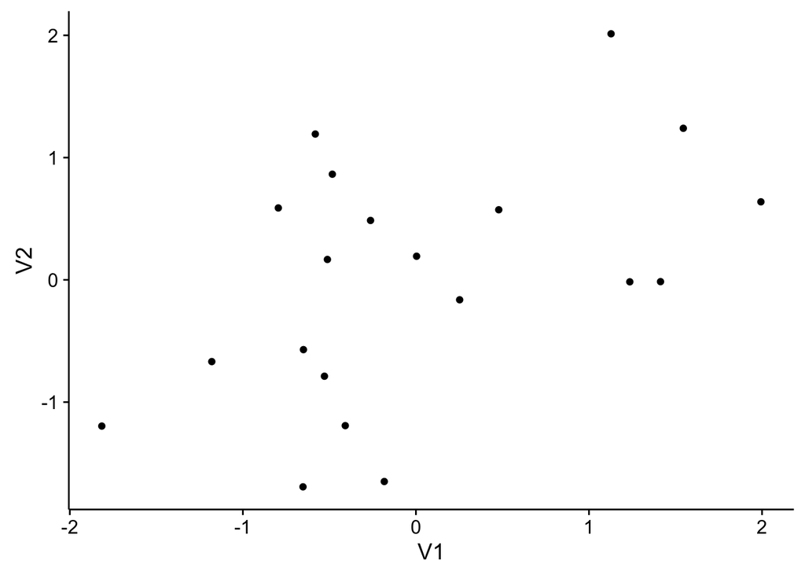

```r
set.seed(10)  # Set the random number generator seed
rho <- 0.5    # Desired correlation coefficient
mu <- c(0, 0) # Means for V1 and V2
sigma <- 1    # Standard deviations of V1 and V2
n <- 20       # Number of data points to simulate

# Construct the covariance matrix
Sigma <- matrix(c(sigma^2, rho*sigma^2, rho*sigma^2, sigma^2), 2)

# Simulate the data
x <- MASS::mvrnorm(n, mu, Sigma, empirical = TRUE)
ggplot(as.data.frame(x), aes(V1, V2)) + geom_point()
```

```r
# Perform PCA
# Because x is a matrix, we don't need a formula
# Note center = TRUE is the default but scale. = TRUE is not to make the results compatible with S. You should always use scale. = TRUE
z <- prcomp(x, center = TRUE, scale. = TRUE)
summary(z)
```

```
## Importance of components:
##                          PC1    PC2
## Standard deviation     1.225 0.7071
## Proportion of Variance 0.750 0.2500
## Cumulative Proportion  0.750 1.0000
```

### Activity

Rerun the code above, changing different parameters as you go, to answer the following questions, which are designed to allow you to explore the relationship between data and PCA. You should be able to just change values and then execute the whole chunk.

1. Keeping `rho`, `sigma`, and `n` constant, how does changing `mu` influence the proportion of variance accounted for by `V1` and `V2`? Briefly explain.

> No change, because the data are centered prior to PCA.
2. Keeping `rho`, `mu`, and `sigma` constant, how does changing `n` influence the proportion of variance accounted for by `V1` and `V2`? Briefly explain.

> No change, because the correlation does not depend on `n`.
3. Keeping `rho`, `mu`, and `n` constant, how does changing `sigma` influence the proportion of variance accounted for by `V1` and `V2`? Briefly explain.

> No change, because the data are scaled prior to PCA.
4. Keeping `mu`, `sigma`, and `n` constant, how does changing `rho` influence the proportion of variance accounted for by `V1` and `V2`? Be sure to explore the full possible range of `rho`. Briefly explain.

> As `rho` increases, the proportion of variable accounted for by the first PC increases.

## 2. Return of the Sole

In Week 8, we looked at presence/absence data for the common sole ([*Solea solea*](https://en.wikipedia.org/wiki/Common_sole)) predicted by different factors such as the salinity of the water and the season. Today we will focus on the composition of the substrate.

### Activity

Load the sole data from the file `Sole.xlsx`. Several of the variables are categorical and should be converted into factors: season, month, area, and Solea_solea. Go ahead and do this now. As a final step, convert your object with the data into a `data.frame` with `as.data.frame()`.

```r
# FIXME
M <- read_excel("../data/Sole.xlsx")
M <- M %>% mutate(season = factor(season),
                  month = factor(month),
                  area = factor(area),
                  Solea_solea = factor(Solea_solea))
M <- M %>% as.data.frame()
str(M)
```

```
## 'data.frame':    65 obs. of  13 variables:
##  $ Sample       : num  1 2 3 4 5 6 7 8 9 10 ...
##  $ season       : Factor w/ 2 levels "1","2": 1 1 1 1 1 1 1 1 1 1 ...
##  $ month        : Factor w/ 5 levels "5","6","7","8",..: 1 1 1 1 1 1 1 1 1 1 ...
##  $ area         : Factor w/ 4 levels "1","2","3","4": 2 2 2 4 4 4 3 3 3 1 ...
##  $ depth        : num  3 2.6 2.6 2.1 3.2 3.5 1.6 1.7 1.8 4.5 ...
##  $ temperature  : num  20 18 19 20 20 20 19 17 19 21 ...
##  $ salinity     : num  30 29 30 29 30 32 29 28 29 12 ...
##  $ transparency : num  15 15 15 15 15 7 15 10 10 35 ...
##  $ gravel       : num  3.74 1.94 2.88 11.06 9.87 ...
##  $ large_sand   : num  13.15 4.99 8.98 11.96 28.6 ...
##  $ med_fine_sand: num  11.93 5.43 16.85 21.95 19.49 ...
##  $ mud          : num  71.2 87.6 71.3 55 42 ...
##  $ Solea_solea  : Factor w/ 2 levels "0","1": 1 1 2 1 1 1 2 2 1 2 ...
```

The columns `gravel`, `large_sand`, `med_fine_sand`, and `mud` represent their proportional concentrations in the substrate (they sum to 100). Calculate a composite score for "substrate". Use principal components analysis on these columns.

```r
# FIXME
z <- prcomp(~ gravel + large_sand + med_fine_sand + mud,
              data = M,
              scale. = TRUE,
              center = TRUE)
```

Use the `summary()` and `print()` methods to determine the percent of variance accounted for by each PC and the relative loadings of each variable.

```r
summary(z)
```

```
## Importance of components:
##                           PC1    PC2     PC3       PC4
## Standard deviation     1.5757 1.0760 0.59937 0.0001405
## Proportion of Variance 0.6207 0.2895 0.08981 0.0000000
## Cumulative Proportion  0.6207 0.9102 1.00000 1.0000000
```

```r
z
```

```
## Standard deviations:
## [1] 1.5757246026 1.0760315045 0.5993731377 0.0001405485
##
## Rotation:
##                       PC1        PC2        PC3        PC4
## gravel         0.03170532  0.9136031 -0.2941610 -0.2789149
## large_sand    -0.56786795  0.1266251  0.7093429 -0.3979004
## med_fine_sand -0.54499223 -0.3213332 -0.6308753 -0.4491378
## mud            0.61603915 -0.2145705  0.1108978 -0.7497712
```

Fit a logistic regression where presence of sole is predicted by the first PC from the PCA above. Refer to the lecture slides if you need to.

```r
# FIXME
fm2 <- glm(Solea_solea ~ z$x[, 1], data = M, family = "binomial")
```

5. Try to interpret the output of the summary of the fitted model from part d. Why kind of substrate do sole appear to prefer?

```r
# FIXME
summary(fm2)
```

```
##
## Call:
## glm(formula = Solea_solea ~ z$x[, 1], family = "binomial", data = M)
##
## Deviance Residuals:
##     Min       1Q   Median       3Q      Max
## -1.7794  -0.8275  -0.6165   1.0477   1.9427
##
## Coefficients:
##             Estimate Std. Error z value Pr(>|z|)
## (Intercept)  -0.4643     0.2778  -1.672  0.09461
## z$x[, 1]     -0.5670     0.1887  -3.004  0.00266
##
## (Dispersion parameter for binomial family taken to be 1)
##
##     Null deviance: 87.492  on 64  degrees of freedom
## Residual deviance: 76.885  on 63  degrees of freedom
## AIC: 80.885
##
## Number of Fisher Scoring iterations: 4
```

> PC is basically as axis of sand (large, medium, fine) with values in negative PC1 scores to mud in positive PC1 scores. Gravel doesn't load appreciably on PC1. Logistic regression shows that as PC1 score increases, sole are less likely to be present (negative coefficient estimate). So sole are less likely to be present as the substrate gets more muddy. They are more likely to be present as the substrate gets more sandy.

## 2. Egyptian skulls

The file `Egyptian_Skulls.xlsx` contains 4 measurements of 150 skulls from 5 time periods of Egypt from Thompson and Randall-Maciver (1905). Here is an image of the measurements that I found online (with typos):

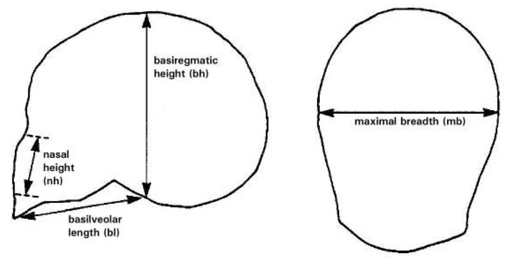

We will explore this data set and try to predict some of the measurements.

Thompson, A. and Randall-Maciver, R. (1905) *Ancient races of the Thebaid: Being an Anthropometrical Study of the Inhabitants of Upper Egypt from the Earliest Prehistoric Times to the Mohammedan Conquest, Based Upon the Examination of Over 1,500 Crania*. Oxford University Press.

### Activity

1. Load the file. Convert `Time_Period` to a factor. Group by `Time_Period` and use `tally()` to confirm that there are 30 skulls per time period. Also, relevel the time periods so they go in chronological order.

```r
# FIXME
M <- read_excel("../data/Egyptian_Skulls.xlsx")
M <- M %>% mutate(Time_Period = factor(Time_Period))
M %>% group_by(Time_Period) %>% tally()
```

```
## # A tibble: 5 × 2
##   Time_Period     n
##        <fctr> <int>
## 1      150_AD    30
## 2     1850_BC    30
## 3      200_BC    30
## 4     3300_BC    30
## 5     4000_BC    30
```

```r
M$Time_Period <- relevel(M$Time_Period, ref = "200_BC")
M$Time_Period <- relevel(M$Time_Period, ref = "1850_BC")
M$Time_Period <- relevel(M$Time_Period, ref = "3300_BC")
M$Time_Period <- relevel(M$Time_Period, ref = "4000_BC")
```

2. Use MANOVA to predict `Maximum_Breadth`, `Basibregmatic_Height` `Basialveolar_Length`, and `Nasal_Height` from `Time_Period` using the `lm()` function (see the lecture notes).

```r
# FIXME
fm <- lm(cbind(Maximum_Breadth, Basibregmatic_Height,
               Basialveolar_Length, Nasal_Height) ~ Time_Period,
         data = M)
```

3. Generate the MANOVA table with `Anova()` using type III sums of squares.

```r
# FIXME
Anova(fm, type = "III")
```

```
##
## Type III MANOVA Tests: Pillai test statistic
##             Df test stat approx F num Df den Df    Pr(>F)
## (Intercept)  1   0.99736  13410.5      4    142 < 2.2e-16
## Time_Period  4   0.35331      3.5     16    580 4.675e-06
```

4. What is your interpretation of the results of the MANOVA?

> Collectively the multivariate measurements vary by time periods.
5. We can also flip the analysis around and try to classify skulls by time period by their measurements. Use discriminant function analysis (linear discriminant analysis) to classify skulls by time period. See the lecture notes.

```r
# FIXME
skulls_lda <- lda(Time_Period ~ ., data = M)
```

6. Calculate the percent correct classification for the DFA using the full dataset.

```r
# FIXME
skulls_predict <- predict(skulls_lda, M[, 1:4])
skulls_classify <- skulls_predict$class
mean(skulls_classify == M$Time_Period)
```

```
## [1] 0.34
```

7. Generate the confusion matrix for the classification. Are there any patterns as to which time periods are best or worst predicted?

```r
# FIXME
table(Original = M$Time_Period, Predicted = skulls_classify)
```

```
##          Predicted
## Original  4000_BC 3300_BC 1850_BC 200_BC 150_AD
##   4000_BC      12       8       4      4      2
##   3300_BC      10       8       5      4      3
##   1850_BC       4       4      15      2      5
##   200_BC        3       3       7      5     12
##   150_AD        2       4       4      9     11
```

> They are all actually pretty mediocre. Only 34% are correctly classified.
8. Now use the `CV=TRUE` option to perform leave-one-out cross validation (see the help for `lda()`).

```r
# FIXME
skulls_lda <- lda(Time_Period ~ ., data = M, CV=TRUE)

ct <- table(M$Time_Period, skulls_lda$class)
#% correct for each time period
diag(prop.table(ct, 1))
```

```
##   4000_BC   3300_BC   1850_BC    200_BC    150_AD
## 0.3000000 0.2333333 0.4000000 0.1666667 0.3333333
```

```r
# total percent correct
sum(diag(prop.table(ct)))
```

```
## [1] 0.2866667
```

How does the percent correct compare to using the full data set to estimate this quantity? Explain why you observe a difference.

## 3. Pottery

The file `pottery.xslx` contains data on the chemical composition (oxides) of 45 samples of Romano-British pottery as well as a column (`kiln`) to indicate the source of the pottery.

A. Tubb and N. J. Parker and G. Nickless (1980), The analysis of Romano-British pottery by atomic absorption spectrophotometry. *Archaeometry*, 22, 153-171.

### Activity

1. Load the file `pottery.xslx` and check the structure, and create a new object having dropped the column `kiln`. This will leave you with 9 columns of data in your new object. We will return to the `data.frame` with `kiln` later.

```r
# FIXME
M.all <- read_excel("../data/pottery.xlsx")
M <- M.all %>% dplyr::select(-kiln)
```

KEVIN - I HAD TO SPECIFY DPLYR TO GET THIS TO GO.

2. Calculate the principal components using centered and scaled data.

```r
# FIXME
z <- prcomp(~., M, center = TRUE, scale. = TRUE)
```

3. Using the `summary()` output: (1) what percentage of the variance does PC1 account for? (2) What percentage of the variation do the first 5 PCs cumulatively account for?

```r
summary(z)
```

```
## Importance of components:
##                           PC1    PC2     PC3     PC4     PC5     PC6
## Standard deviation     2.0503 1.5885 0.93699 0.67538 0.61647 0.51840
## Proportion of Variance 0.4671 0.2804 0.09755 0.05068 0.04223 0.02986
## Cumulative Proportion  0.4671 0.7475 0.84501 0.89570 0.93792 0.96778
##                            PC7     PC8    PC9
## Standard deviation     0.34325 0.30190 0.2846
## Proportion of Variance 0.01309 0.01013 0.0090
## Cumulative Proportion  0.98087 0.99100 1.0000
```

> PC1 accounts for 47% of the variance. PCs 1-5 account for 94% of the variance.
4. Using the `print()` method for a `prcomp` object, (1) what variables load positively on PC1? (2) What variables load negatively on PC1? (3) What variables have minimal loading on PC1?

```r
z
```

```
## Standard deviations:
## [1] 2.0503433 1.5884850 0.9369854 0.6753828 0.6164727 0.5183982 0.3432531
## [8] 0.3019006 0.2845736
##
## Rotation:
##               PC1         PC2          PC3         PC4         PC5
## Al2O3 -0.34829631  0.32780562  0.119014979 -0.03608198  0.32219091
## Fe2O3  0.32709620  0.39525949 -0.264444108 -0.02114131  0.34343318
## MgO    0.43456923 -0.18964741  0.150918366  0.05350702  0.28126791
## CaO    0.06428531  0.50119655 -0.477928669 -0.49719394 -0.06858469
## Na2O   0.21717586  0.45551237 -0.007020976  0.57759974 -0.53034971
## K2O    0.45633257 -0.01837517  0.102097013 -0.03872041  0.38892815
## TiO2  -0.34019754  0.30078403  0.089583383  0.49161094  0.49299846
## MnO    0.45522720  0.08753781  0.140202878  0.15303057 -0.02199131
## BaO    0.01854192  0.37839957  0.791553826 -0.38466339 -0.13551441
##                PC6          PC7         PC8         PC9
## Al2O3 -0.776136871 -0.017576097  0.21945465 -0.03319629
## Fe2O3 -0.045613182  0.243749457 -0.50439926  0.48222510
## MgO   -0.009243254 -0.442140420  0.49189525  0.48259499
## CaO    0.226593748 -0.171170581  0.39348466 -0.16992250
## Na2O  -0.157645754 -0.321107660 -0.04474717 -0.02090327
## K2O   -0.078842428 -0.309777858 -0.28554772 -0.66672244
## TiO2   0.520801535 -0.005608328  0.14702257 -0.09032883
## MnO   -0.048867577  0.718184163  0.42728179 -0.20199070
## BaO    0.198520122 -0.024441118 -0.11359903  0.10329608
```

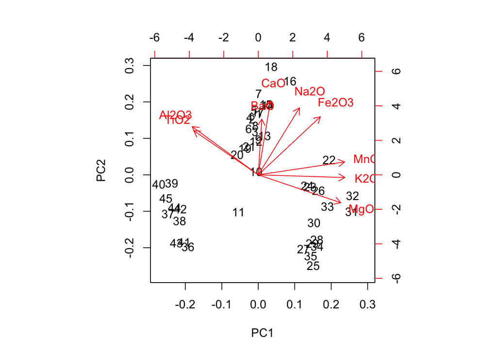

```r
biplot(z)
```

> Al2O3 and TiO2 load together. BaO, CaO, Na2O, and Fe2O3 cluster together. MnO, K2O, and MgO also load similarly.
6. Return to the full dataset including the `kiln` column. Convert `kiln` to a factor

```r
# FIXME
M.all$kiln <- factor(M.all$kiln)
```

7. Perform discriminant function analysis on the kiln column predicted by the first 9 variables. Calculate the percent correct classification for the full set (as for question 2, part f).

```r
# FIXME
pottery_lda <- lda(kiln ~ ., data = M.all)
pottery_predict <- predict(pottery_lda, M.all[, 1:9])
pottery_classify <- pottery_predict$class
mean(pottery_classify == M.all$kiln)
```

```
## [1] 0.9111111
```

8. Calculate the confusion table for the classification.

```r
# FIXME
table(Original = M.all$kiln, Predicted = pottery_classify)
```

```
##         Predicted
## Original  1  2  3  4  5
##        1 21  0  0  0  0
##        2  0 12  0  0  0
##        3  0  0  2  0  0
##        4  0  0  0  2  3
##        5  0  0  0  1  4
```

1. Use the `CV = TRUE` option to perform cross validation and calculate the % correct and confusion table as in question 2, part h.

```r
# FIXME
pottery_lda <- lda(kiln ~ ., data = M.all, CV=TRUE)

ct <- table(M.all$kiln, pottery_lda$class)
#% correct for each time period
diag(prop.table(ct, 1))
```

```
##   1   2   3   4   5
## 1.0 1.0 1.0 0.0 0.2
```

```r
# total percent correct
sum(diag(prop.table(ct)))
```

```
## [1] 0.8
```

10. A piece of pottery is found, but it's source is unknown. Chemical analysis reveals the following composition. Predict the source kiln it came from. Which kiln has the highest posterior probability? Use the `lda()` performed without `CV=TRUE` as that changes the structure of the output and won't work with `predict()`.
- Al2O3: 12.1
- Fe2O3: 5.61
- MgO: 5.55
- CaO: 0.16
- Na2O: 0.19
- K2O: 4.45
- TiO2: 0.71
- MnO: 0.991
- BaO: 0.016

```r
# FIXME
pottery_lda <- lda(kiln ~ ., data = M.all)

pottery_new <- data.frame(
  Al2O3 = 12.1,
  Fe2O3 = 5.61,
  MgO = 5.55,
  CaO = 0.16,
  Na2O = 0.19,
  K2O = 4.45,
  TiO2 = 0.71,
  MnO = 0.991,
  BaO = 0.016)
predict(pottery_lda, pottery_new)
```

```
## $class
## [1] 3
## Levels: 1 2 3 4 5
##
## $posterior
##               1            2         3             4             5
## 1 8.944609e-164 9.247538e-08 0.9999999 3.150289e-239 2.476519e-229
##
## $x
##        LD1      LD2      LD3     LD4
## 1 28.34386 17.68174 4.649118 12.5918
```

> The posterior probability is >99% for kiln 3.

KEVIN - SHOULD WE DO THIS EXAMPLE WITH A LOGISTIC REGRESSION TO SHOW COMPARISION?